# Acerca de las MTBI

# ¿Qué es la prueba MTBI?

El test Myers Briggs Type Indicator o abreviado MBTI, es una herramienta para clasificar diferentes tipos de personalidad. Ayuda a conocer los rasgos psicológicos dominantes de una persona.

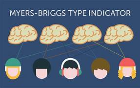

# *¿Quién lo propuso?*

A partir de la propuesta de *Carl Gustav Jung* sobre la existencia de tipos psicológicos publicado en un artículo de 1921. *Isabel Briggs Myers* y *Katherine Cook Briggs* durante 40 desarrollarón el test MTBI.

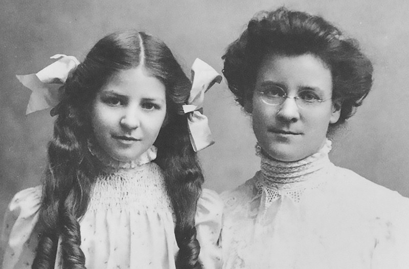

# *Bases de test MBTI*

Se basa en la teoría conceptual de *Carl Gustav Jung*. El cual sustenta que los seres humanos sentimos el mundo a partir de *cuatro funciones psicológicas principales*, durante nuestra vida una será predominante. Las teorías de Jung hablarón de *cuatro funciones cognitivas* (pensamiento, sentimiento, sensación e intuición) cada una de ellas orientada hacia la extroversión o introversión. Resultando en ocho funciones dominantes.

# *¿Qué determina el MBTI?*

Mediante el test MTBI se determina la función dominante y auxiliar del individuo. Los cuatro ejes son:

1. Orientación de la energía (Introversión/Extroversión)(I/E)
2. Recopilación de información (Sensorial/Intuitivo)(S/N)
3. Toma de decisiones (Racionalidad/Emoción)(T/F)
4. Modo de acción (Juicio/Percepción)(J/P)

Lo que da como resultado los 16 tipos de personalidad

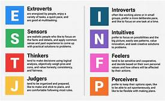

# *Los 16 tipos de personalidad*

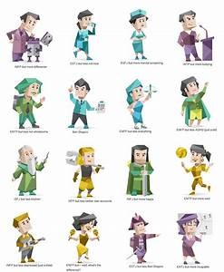

### Los racionales

Buscan conocimiento:

- Los Ingenieros:

+El Inventor: ENTP (Extraversión, Intuición, Racionalidad, Percepción) +El Arquitecto: INTP (Introversión, Intuición, Racionalidad, Percepción)

- Los Coordinadores:

+El Mariscal: ENTJ (Extraversión, Intuición, Racionalidad, Juicio) +El Mente Maestra: INTJ (Introversión, Intuición, Racionalidad, Juicio)

### Los idealistas

Buscan identidad:

- Los Abogados:

+El Campeón: ENFP (Extraversión, Intuición, Emoción, Percepción) +El Sanador: INFP (Introversión, Intuición, Emoción, Percepción)

- Los Mentores:

+El Profesor: ENFJ (Extraversión, Intuición, Emoción, Juicio) +El Consejero: INFJ (Introversión, Intuición, Emoción, Juicio)

### Los centinelas

Son los que buscan la seguridad:

- Los Protectores:

+El Proveedor: ESFJ (Extraversión, Sensorialidad, Emoción, Juicio) +El Protector: ISFJ (Introversión, Sensorialidad, Emoción, Juicio)

- Los Gestores:

+El Supervisor: ESTJ (Extraversión, Sensorialidad, Racionalidad, Juicio) +El Inspector: ISTJ (Introversión, Sensorialidad, Racionalidad, Juicio)

### Los artesanos

Buscan sensaciones:

-Los Bromistas:

+El Artista: ESFP (Extraversión, Sensorialidad, Emoción, Percepción) +El Compositor: ISFP (Introversión, Sensorialidad, Emoción, Percepción)

-Los Operadores:

+El Promotor: ESTP (Extraversión, Sensorialidad, Racionalidad, Percepción) +El Artesano: ISTP (Introversión, Sensorialidad, Racionalidad, Percepción)

# *¿Cómo lo usaremos en este programa?*

En este programa lo usaremos para evaluar si según tu MTBI sobrevivirías a un apocalipsis zombie. Integrando bases de datos que contienen el tipo de personalidad de cada personaje de la serie de *“The Walking dead”*.